# Gapminder

Nuo Wei

12/13/2022

# 1 Introduction & Objections

The general information of every country plays a very important role in analyzing the average situations of every country and exploring what variables may affect each other in the especially continent or country in order to improve global public health. Gapminder(https://www.gapminder.org/data/) is an independent educational non-proﬁt ﬁghting global misconceptions. In addition, the data from WHO, World Bank, and United Nations to make sure that all sources are reliable and valuable.

We have used data from Gapminder. But it needs to be completed. In this project, I will extend what we did in homework 3, and study life expectancy, population, income, child mortality, CO2 emission per person, and Babies per woman in order to explore the relationship between those values with continents or regions.

There are some questions I aim to in this project.

1. Changes in the number of countries in each region over time
2. Changes in the value of gdpminder over time
3. The distribution values of gdpminder in each region.
4. The correlation coefficient of gdpminder
5. The variables may make influence the baby per woman.

# 2 Data import & Clean

## 2.1 Importing Dataset from file

In this step, importing and read downloaded csv files from Gapminder website.

```r
#life expectancy, population, income, child mortality, CO2 emission per person and Babies per woman

life_ex <- read_csv("D:/University of Pittsburgh/BIOST 2036 Intro to health data science/Project-Nuo Wei/life_expectancy_years.csv")

popu <- read_csv("D:/University of Pittsburgh/BIOST 2036 Intro to health data science/Project-Nuo Wei/population_total.csv")

income <- read_csv("D:/University of Pittsburgh/BIOST 2036 Intro to health data science/Project-Nuo Wei/income_per_person_gdppercapita_ppp_inflation_adjusted.csv")

child_mortality <- read_csv("D:/University of Pittsburgh/BIOST 2036 Intro to health data science/Project-Nuo Wei/child_mortality_0_5_year_olds_dying_per_1000_born.csv")

CO2 <- read_csv("D:/University of Pittsburgh/BIOST 2036 Intro to health data science/Project-Nuo Wei/co2_emissions_tonnes_per_person.csv")

baby <- read_csv("D:/University of Pittsburgh/BIOST 2036 Intro to health data science/Project-Nuo Wei/children_per_woman_total_fertility.csv")
```

## 2.2 Unit function

From those downloaded CSV files, I noticed that there are units such as “K”, “M”, and “B” in those datasets such as population and income. For researching the next step, I should convert those units into a number. I wrote a function like this.

```r
func <- function(x) {
  for(i in 1:NROW(x))
    x[i] <- eval(parse(text=str_replace_all(x[i], c("k" = "*1000",
                                                        "M" = "*1000000",
                                                        "B" = "*1000000000"
                                                        ))))
  x
}
```

There is an example that can make sure this function working well.

```r
DF <- data.frame(country = c("A", "B"),
                 `1799` = c("8.1M", "3k"),
                 `1800` = c("2400", "75M"),
                 `1801` = c("6.04k", "23"),check.names = FALSE)
DF
```

```
##   country 1799 1800  1801
## 1       A 8.1M 2400 6.04k
## 2       B   3k  75M    23
```

```r
DF1 <- DF %>% mutate(across(.cols = -country,
                          .fns = ~func(.x)))
DF1
```

```
##   country    1799    1800 1801
## 1       A 8100000    2400 6040
## 2       B    3000 7.5e+07   23
```

Applying this function to the variables population and income which containing those numerical units I was confused.

```r
popu <- popu %>% mutate(across(.cols = -country,
                          .fns = ~func(.x)))
popu
```

```
## # A tibble: 197 x 302
##    country `1799` `1800` `1801` `1802` `1803` `1804` `1805` `1806` `1807` `1808`
##    <chr>   <chr>  <chr>  <chr>  <chr>  <chr>  <chr>  <chr>  <chr>  <chr>  <chr>
##  1 Afghan~ 32800~ 32800~ 32800~ 32800~ 32800~ 32800~ 32800~ 32800~ 32800~ 32800~
##  2 Angola  15700~ 15700~ 15700~ 15700~ 15700~ 15700~ 15700~ 15700~ 15700~ 15700~
##  3 Albania 4e+05  402000 404000 405000 407000 409000 411000 413000 414000 416000
##  4 Andorra 2650   2650   2650   2650   2650   2650   2650   2650   2650   2650
##  5 United~ 40200  40200  40200  40200  40200  40200  40200  40200  40200  40200
##  6 Argent~ 534000 520000 506000 492000 479000 466000 453000 441000 429000 417000
##  7 Armenia 413000 413000 413000 413000 413000 413000 413000 413000 413000 413000
##  8 Antigu~ 37000  37000  37000  37000  37000  37000  37000  37000  37000  37000
##  9 Austra~ 2e+05  205000 211000 216000 222000 227000 233000 239000 246000 252000
## 10 Austria 3e+06  30200~ 30400~ 30500~ 30700~ 30900~ 31100~ 31200~ 31400~ 31600~
## # ... with 187 more rows, and 291 more variables: `1809` <chr>, `1810` <chr>,
## #   `1811` <chr>, `1812` <chr>, `1813` <chr>, `1814` <chr>, `1815` <chr>,
## #   `1816` <chr>, `1817` <chr>, `1818` <chr>, `1819` <chr>, `1820` <chr>,
## #   `1821` <chr>, `1822` <chr>, `1823` <chr>, `1824` <chr>, `1825` <chr>,
## #   `1826` <chr>, `1827` <chr>, `1828` <chr>, `1829` <chr>, `1830` <chr>,
## #   `1831` <chr>, `1832` <chr>, `1833` <chr>, `1834` <chr>, `1835` <chr>,
## #   `1836` <chr>, `1837` <chr>, `1838` <chr>, `1839` <chr>, `1840` <chr>, ...
```

```r
income <- income %>% mutate(across(.cols = -country,
                          .fns = ~func(.x)))
income
```

```
## # A tibble: 195 x 252
##    country `1799` `1800` `1801` `1802` `1803` `1804` `1805` `1806` `1807` `1808`
##    <chr>    <dbl>  <dbl>  <dbl>  <dbl>  <dbl>  <dbl>  <dbl>  <dbl>  <dbl>  <dbl>
##  1 Afghan~    683    683    683    683    683    683    683    683    683    683
##  2 Angola     700    702    705    709    711    714    718    721    725    727
##  3 Albania    755    755    755    755    755    756    756    756    756    756
##  4 Andorra   1360   1360   1360   1360   1370   1370   1370   1370   1380   1380
##  5 United~   1130   1130   1140   1140   1150   1150   1160   1160   1160   1170
##  6 Argent~   1730   1730   1740   1740   1750   1760   1760   1770   1770   1780
##  7 Armenia    582    582    582    582    582    582    582    582    582    582
##  8 Antigu~    857    857    857    857    857    857    857    858    858    858
##  9 Austra~    925    930    936    941    947    952    956    962    968    973
## 10 Austria   2090   2100   2110   2120   2130   2130   2140   2150   2160   2170
## # ... with 185 more rows, and 241 more variables: `1809` <dbl>, `1810` <dbl>,
## #   `1811` <dbl>, `1812` <dbl>, `1813` <dbl>, `1814` <dbl>, `1815` <dbl>,
## #   `1816` <dbl>, `1817` <dbl>, `1818` <dbl>, `1819` <dbl>, `1820` <dbl>,
## #   `1821` <dbl>, `1822` <dbl>, `1823` <dbl>, `1824` <dbl>, `1825` <dbl>,
## #   `1826` <dbl>, `1827` <dbl>, `1828` <dbl>, `1829` <dbl>, `1830` <dbl>,
## #   `1831` <dbl>, `1832` <dbl>, `1833` <dbl>, `1834` <dbl>, `1835` <dbl>,
## #   `1836` <dbl>, `1837` <dbl>, `1838` <dbl>, `1839` <dbl>, `1840` <dbl>, ...
```

# 3 Merging with Years and regions of gdpminder

## 3.1 Selecting data columns from 1960 to 2020

Using `pivot_longer` to clear data, and letting population and income be numeric.

```r
life_ex_tidy <- life_ex %>% select(country,c(as.character("1960":"2020"))) %>%
  pivot_longer(c(as.character("1960":"2020")), names_to = "year", values_to = "life_expectancy")


popu_tidy <- popu %>% select(country,c(as.character("1960":"2020"))) %>%
  pivot_longer(c(as.character("1960":"2020")), names_to = "year", values_to = "population") %>%
  mutate(population=as.numeric(population))


income_tidy <- income %>% select(country,c(as.character("1960":"2020"))) %>%
  pivot_longer(c(as.character("1960":"2020")), names_to = "year", values_to = "income") %>%
  mutate(income = as.numeric(income))

child_mortality_tidy <- child_mortality %>% select(country,c(as.character("1960":"2020"))) %>%
  pivot_longer(c(as.character("1960":"2020")), names_to = "year", values_to = "child_mortality")


CO2_tidy <- CO2 %>% select(country,c(as.character("1960":"2017"))) %>%
  pivot_longer(c(as.character("1960":"2017")), names_to = "year", values_to = "CO2")


baby_tidy <- baby %>% select(country,c(as.character("1960":"2020"))) %>%
  pivot_longer(c(as.character("1960":"2020")), names_to = "year", values_to = "baby")
```

And, combing multiple CSV files from 1960 to 2020.

Using `lefe_jion` to combine those information together by country and year.

```r
Study <- left_join(life_ex_tidy, popu_tidy)
Study <- left_join(Study, income_tidy)
Study <- left_join(Study, child_mortality_tidy)
Study <- left_join(Study, CO2_tidy)
Study <- left_join(Study, baby_tidy)
Study <- drop_na(Study)
Study
```

```
## # A tibble: 10,557 x 8
##    country     year  life_expectancy population income child_mort~1    CO2  baby
##    <chr>       <chr>           <dbl>      <dbl>  <dbl>        <dbl>  <dbl> <dbl>
##  1 Afghanistan 1960             45.3    9170000   1520          351 0.0536  7.45
##  2 Afghanistan 1961             45.5    9350000   1510          345 0.0737  7.45
##  3 Afghanistan 1962             45.7    9540000   1510          340 0.0741  7.45
##  4 Afghanistan 1963             45.9    9740000   1500          335 0.0861  7.45
##  5 Afghanistan 1964             46.1    9960000   1500          330 0.101   7.45
##  6 Afghanistan 1965             46.3   10200000   1480          324 0.107   7.45
##  7 Afghanistan 1966             46.5   10400000   1480          319 0.123   7.45
##  8 Afghanistan 1967             46.7   10600000   1500          314 0.115   7.45
##  9 Afghanistan 1968             46.9   10900000   1490          308 0.0865  7.45
## 10 Afghanistan 1969             47.1   11200000   1480          303 0.15    7.45
## # ... with 10,547 more rows, and abbreviated variable name 1: child_mortality
```

## 3.2 Location of world

I used the information on regions and continents from `dslabs` package as in our course.

```r
data(gapminder)
#colnames(gapminder)

gapminder[1:10,]
```

```
##                country year infant_mortality life_expectancy fertility
## 1              Albania 1960           115.40           62.87      6.19
## 2              Algeria 1960           148.20           47.50      7.65
## 3               Angola 1960           208.00           35.98      7.32
## 4  Antigua and Barbuda 1960               NA           62.97      4.43
## 5            Argentina 1960            59.87           65.39      3.11
## 6              Armenia 1960               NA           66.86      4.55
## 7                Aruba 1960               NA           65.66      4.82
## 8            Australia 1960            20.30           70.87      3.45
## 9              Austria 1960            37.30           68.75      2.70
## 10          Azerbaijan 1960               NA           61.33      5.57
##    population          gdp continent                    region
## 1     1636054           NA    Europe           Southern Europe
## 2    11124892  13828152297    Africa           Northern Africa
## 3     5270844           NA    Africa             Middle Africa
## 4       54681           NA  Americas                 Caribbean
## 5    20619075 108322326649  Americas             South America
## 6     1867396           NA      Asia              Western Asia
## 7       54208           NA  Americas                 Caribbean
## 8    10292328  96677859364   Oceania Australia and New Zealand
## 9     7065525  52392699681    Europe            Western Europe
## 10    3897889           NA      Asia              Western Asia
```

## 3.3 Removing Duplicates and NA

From `dslabs` package, I select the continent and region for each country and convert those variables into characters. However, there is some duplicated information such as one row of detailed situations of a country repeated a number of times. In this case, I should keep only one I need and remove all `NA` values.

```r
place <- gapminder%>% select(country, continent, region)%>%
  mutate(country = as.character(country)) %>%
  mutate(continent = as.character(continent)) %>%
  mutate(region = as.character(region)) %>%
  distinct() %>% drop_na()

place[1:10,]
```

```
##                country continent                    region
## 1              Albania    Europe           Southern Europe
## 2              Algeria    Africa           Northern Africa
## 3               Angola    Africa             Middle Africa
## 4  Antigua and Barbuda  Americas                 Caribbean
## 5            Argentina  Americas             South America
## 6              Armenia      Asia              Western Asia
## 7                Aruba  Americas                 Caribbean
## 8            Australia   Oceania Australia and New Zealand
## 9              Austria    Europe            Western Europe
## 10          Azerbaijan      Asia              Western Asia
```

## 3.4 Merging with information and region

Using `lefe_jion` to combine gdpminder information and region together by country and year.

```r
Study1 <- left_join(Study, place, by = "country")
Study1 <- Study1 %>% drop_na()

Study1[1:10,]
```

```
## # A tibble: 10 x 10
##    country year  life_expec~1 popul~2 income child~3    CO2  baby conti~4 region
##    <chr>   <chr>        <dbl>   <dbl>  <dbl>   <dbl>  <dbl> <dbl> <chr>   <chr>
##  1 Angola  1960          44.8 5530000   2590     305 0.0821  7.52 Africa  Middl~
##  2 Angola  1961          45   5610000   2470     302 0.21    7.56 Africa  Middl~
##  3 Angola  1962          45.2 5680000   2560     298 0.203   7.59 Africa  Middl~
##  4 Angola  1963          45.4 5730000   2800     295 0.213   7.61 Africa  Middl~
##  5 Angola  1964          45.6 5770000   2960     291 0.206   7.62 Africa  Middl~
##  6 Angola  1965          45.8 5780000   3080     287 0.269   7.62 Africa  Middl~
##  7 Angola  1966          46   5770000   3200     283 0.172   7.61 Africa  Middl~
##  8 Angola  1967          46.2 5770000   3100     279 0.289   7.61 Africa  Middl~
##  9 Angola  1968          46.4 5800000   3130     275 0.48    7.6  Africa  Middl~
## 10 Angola  1969          46.6 5890000   3280     271 0.608   7.6  Africa  Middl~
## # ... with abbreviated variable names 1: life_expectancy, 2: population,
## #   3: child_mortality, 4: continent
```

# 4 Association between data and region

## 4.1 Summarizing data

For the following, I will find the associations between continents or regions with gdpmnder .

Firstly, I should summarize that information and categorize it by years and continents, and regions, in this case, I want to find the general situations of each continent in especially year, so I choose the average all gdpminder values by the number of countries in every year.

```r
grp_gap_data <-
  Study1 %>%
    group_by(year, continent) %>%
    summarize(
      count = n(),
      ave_life   = mean(life_expectancy, na.rm = TRUE),
      ave_popu   = mean(population, na.rm = TRUE),
      ave_income   = mean(income, na.rm = TRUE),
      ave_child_mortality = mean(child_mortality, na.rm = TRUE),
      ave_CO2   = mean(CO2, na.rm = TRUE),
      ave_baby   = mean(baby, na.rm = TRUE),
    )
grp_gap_data
```

```
## # A tibble: 290 x 9
## # Groups:   year [58]
##    year  continent count ave_life  ave_popu ave_income ave_chi~1 ave_CO2 ave_b~2
##    <chr> <chr>     <int>    <dbl>     <dbl>      <dbl>     <dbl>   <dbl>   <dbl>
##  1 1960  Africa       45     46.8  6234278.      2184.     268.    0.346    6.68
##  2 1960  Americas     33     60.5 13073664.      6324.     123.    1.94     5.89
##  3 1960  Asia         41     56.7 41047780.      8954.     165.    2.83     5.97
##  4 1960  Europe       38     69.3 16031526.      9969.      51.5   5.69     2.80
##  5 1960  Oceania       8     60.3  1983238.      6266.     113.    1.83     5.98
##  6 1961  Africa       45     47.6  6388071.      2175.     264.    0.341    6.70
##  7 1961  Americas     33     61.1 13334661.      6528.     119.    2.16     5.85
##  8 1961  Asia         41     57.4 41871605.      9587.     157.    3.12     6.03
##  9 1961  Europe       38     69.2 16209500      10306.      48.9   5.95     2.77
## 10 1961  Oceania       9     59.6  1806700       5879.     113.    1.71     6.05
## # ... with 280 more rows, and abbreviated variable names
## #   1: ave_child_mortality, 2: ave_baby
```

```r
grp_gap_data1 <-
  Study1 %>%
    group_by(year, region) %>%
    summarize(
      count = n(),
      ave_life   = mean(life_expectancy, na.rm = TRUE),
      ave_popu   = mean(population, na.rm = TRUE),
      ave_income   = mean(income, na.rm = TRUE),
      ave_child_mortality = mean(child_mortality, na.rm = TRUE),
      ave_CO2   = mean(CO2, na.rm = TRUE),
      ave_baby   = mean(baby, na.rm = TRUE),
    )


grp_gap_data1
```

```
## # A tibble: 1,276 x 9
## # Groups:   year [58]
##    year  region            count ave_l~1 ave_p~2 ave_i~3 ave_c~4 ave_CO2 ave_b~5
##    <chr> <chr>             <int>   <dbl>   <dbl>   <dbl>   <dbl>   <dbl>   <dbl>
##  1 1960  Australia and Ne~     2    71.2  6.41e6  17050     25.6   6.76     3.56
##  2 1960  Caribbean            11    62.4  1.62e6   5703.   105.    1.42     5.71
##  3 1960  Central America       8    57.2  6.60e6   3875    157.    0.570    6.72
##  4 1960  Central Asia          5    57.8  5.03e6   6006    157.    6.08     5.95
##  5 1960  Eastern Africa       14    48.1  5.61e6   1777.   233.    0.307    7.07
##  6 1960  Eastern Asia          5    56.3  1.59e8   3623.   136.    1.37     4.69
##  7 1960  Eastern Europe       10    68.6  2.56e7   6574     55.1   6.08     2.53
##  8 1960  Melanesia             3    55.1  9.43e5   2380    148.    0.208    6.32
##  9 1960  Micronesia            1    48.6  4.22e4   3310    190     0.174    6.8
## 10 1960  Middle Africa         8    43.4  4.10e6   2584.   264.    0.129    5.99
## # ... with 1,266 more rows, and abbreviated variable names 1: ave_life,
## #   2: ave_popu, 3: ave_income, 4: ave_child_mortality, 5: ave_baby
```

There, I get two nice tidy data of averaged gdpminder values for each continent by year and do the same thing to regions.

## 4.2 Number of country and years

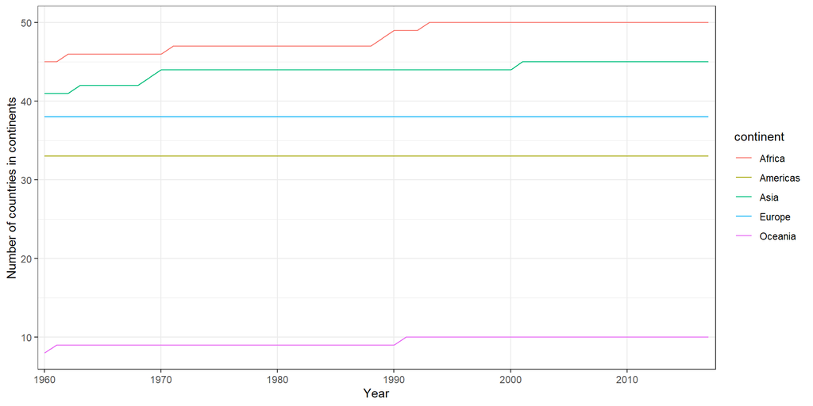

```r
grp_gap_data %>%
  ggplot(aes(color=continent, group=continent)) +
  geom_line(aes(x=year, y=count)) +
  scale_x_discrete(breaks=(c(1960,1970,1980,1990,2000,2010,2020)),
                              labels=c("1960","1970","1980","1990","2000","2010","2020"))+xlab("Year") + ylab("Number of countries in continents") +
      theme_bw()
```

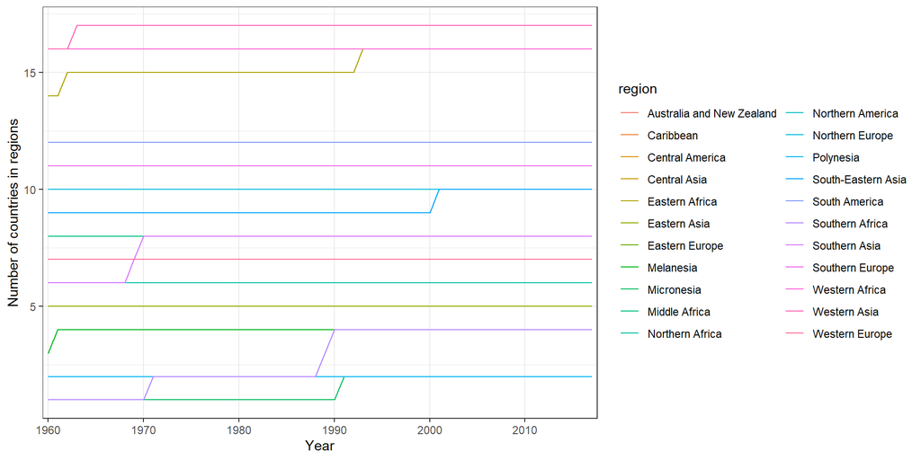

```r
grp_gap_data1 %>%
  ggplot(aes(color=region, group=region)) +
  geom_line(aes(x=year, y=count)) +
  scale_x_discrete(breaks=(c(1960,1970,1980,1990,2000,2010,2020)),
                              labels=c("1960","1970","1980","1990","2000","2010","2020"))+xlab("Year") + ylab("Number of countries in regions") +
      theme_bw()
```

From the plots, I can observe that the number of countries was increasing with the development of time, especially before the 21st century. For some relatively new countries, the information about general is missing due to historical reasons such as Ukraine and some located in Africa or Oceania. From the 1950s to 2000, the world landscape was very turbulent, with many countries seeking independence from colonies evident in Africa and Asia, and the collapse of the Soviet Union leading to the emergence of more European countries.

## 4.3 Gdpminder values and years

There are linear relationships between years and several variables of gdpminder in continents.

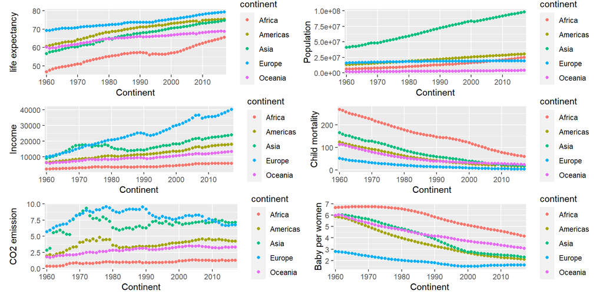

```r
p1 <- grp_gap_data %>%
  ggplot(aes(color=continent, group=continent)) +
  geom_point(aes(x=year, y=ave_life)) +
    xlab("Continent") + ylab("life expectancy") +
  scale_x_discrete(breaks=(c(1960,1970,1980,1990,2000,2010,2020)),
                              labels=c("1960","1970","1980","1990","2000","2010","2020"))

p2 <- grp_gap_data %>% ggplot(aes(color=continent, group=continent)) +
           geom_point(aes(x=year, y=ave_popu)) +
    xlab("Continent") + ylab("Population") +
  scale_x_discrete(breaks=(c(1960,1970,1980,1990,2000,2010,2020)),
                              labels=c("1960","1970","1980","1990","2000","2010","2020"))

p3 <- grp_gap_data %>% ggplot(aes(color=continent, group=continent)) +
           geom_point(aes(x=year, y=ave_income)) +
    xlab("Continent") + ylab("Income") +
  scale_x_discrete(breaks=(c(1960,1970,1980,1990,2000,2010,2020)),
                              labels=c("1960","1970","1980","1990","2000","2010","2020"))


p4 <- grp_gap_data %>% ggplot(aes(color=continent, group=continent)) +
           geom_point(aes(x=year, y=ave_child_mortality)) +
    xlab("Continent") + ylab("Child mortality") +
  scale_x_discrete(breaks=(c(1960,1970,1980,1990,2000,2010,2020)),
                              labels=c("1960","1970","1980","1990","2000","2010","2020"))

p5 <- grp_gap_data %>% ggplot(aes(color=continent, group=continent)) +
           geom_point(aes(x=year, y=ave_CO2)) +
    xlab("Continent") + ylab("CO2 emission") +
  scale_x_discrete(breaks=(c(1960,1970,1980,1990,2000,2010,2020)),
                              labels=c("1960","1970","1980","1990","2000","2010","2020"))

p6 <- grp_gap_data %>% ggplot(aes(color=continent, group=continent)) +
           geom_point(aes(x=year, y=ave_baby)) +
    xlab("Continent") + ylab("Baby per women") +
  scale_x_discrete(breaks=(c(1960,1970,1980,1990,2000,2010,2020)),
                              labels=c("1960","1970","1980","1990","2000","2010","2020"))



(p1 + p2)/(p3 + p4)/(p5 + p6)
```

From the plot we made previously, we can find the relationship between gapminder data and year.

1. In general, With improving science and technology, social welfare is accompanied by time, the trend of average life expectancy, average population, and average income increase for all continents. However, the slopes of each continent are unlikely to be the same based on specific historical, economical, and social situations.
2. European countries have long been leaders in this area due to their better technology and social welfare. It is worth mentioning that until the 1990s, life expectancy in African countries maintained a very high growth rate, but between 1990 and 1995 there was a significant decline in life expectancy, which can be explained by the fact that African societies experienced a large degree of change during this period, such as military coups or wars, but fortunately, it has been maintained since then. Fortunately, the growth rate has remained high since then, but it still lags behind other continents.
3. In terms of population, with the exception of Asia, the world population is not growing very much, and even in Europe, the population curve is almost horizontal. It is well known that Asia has two populous countries, China and India, whose combined population is almost a third of the world. Since the 1970s, the total population of Asia has maintained a high level of growth and I will further explore what are the factors that influence the population.
4. One interesting point on the income side is that there was a very significant fluctuation in income around the world in 2008, and one possible reason for this could be the Financial crisis of 2007-2008, which affected almost the entire world and caused a large degree of recession, and was particularly pronounced in Europe America and Asia.
5. In contrast, average child mortality and average fertility are accompanied by time. Compared to average child mortality, average fertility may be hard to understand, so I will research this part in the next part.
6. In terms of child mortality, with the improvement of medical technology, most of the continent can maintain a very low level now, but Africa still has a gap with other continents in the world even now because of the high child mortality rate in the beginning.
7. Average CO2 emission is the very unique case there, it is relatively not easy to identify the relationship between CO2 emission and time by continent in whole parts. However, as we know, most western countries started to realize the importance of protecting the environment in the 1990s, and the decrease in CO2 emission was very obvious. In addition, there are many developing countries in Asia and the Americas, that would require more natural resources to develop their economy with the cost of pollution, so for the rest of the world, the CO2 emission was increasing with time.

# 5 Relationship between variables

## 5.1 General situation for each continent in 2010

Choosing 2010 as an example.

```r
#Study1
Study1_data <- as_tibble(Study1)
Study11_data <- Study1_data %>% mutate(population=population/1e6)
Study1_data_2010 <-  Study11_data %>% filter(year == 2010)
```

There is a table about the social, economic, and health characteristics of countries on five continents.

```r
#gapData2010


table1::label(Study1_data_2010$life_expectancy) <- "Life Expectancy"
table1::label(Study1_data_2010$population) <- "population"
table1::label(Study1_data_2010$income) <- "income"
table1::label(Study1_data_2010$child_mortality) <- "child_mortality"
table1::label(Study1_data_2010$CO2) <- "CO2"
table1::label(Study1_data_2010$baby) <- "baby"


table1::units(Study1_data_2010$life_expectancy) <- "years"
table1::units(Study1_data_2010$population) <- "million"
table1::units(Study1_data_2010$income) <- "$"
#table1::units(Study1_data_2010$child_mortality) <- ""
table1::units(Study1_data_2010$CO2) <- "tonnes per person"
#table1::units(Study1_data_2010$baby) <- "total fertility"


table1::table1(~life_expectancy + population  + income + child_mortality + CO2 + baby | continent,
               data = Study1_data_2010, overall=FALSE, caption="Social, economic and health characterics of countries in five continents.")
```

Social, economic and health characterics of countries in five continents.

|  | Africa (N=50) | Americas (N=33) | Asia (N=45) | Europe (N=38) | Oceania (N=10) |
| --- | --- | --- | --- | --- | --- |
| Life Expectancy (years) |  |  |  |  |  |
| Mean (SD) | 62.3 (6.36) | 74.8 (4.16) | 73.1 (5.10) | 78.1 (3.83) | 68.1 (8.39) |
| Median [Min, Max] | 61.5 [48.2, 76.2] | 75.4 [60.0, 81.9] | 72.2 [63.6, 83.2] | 80.0 [70.0, 83.0] | 66.1 [57.6, 82.3] |
| population (million) |  |  |  |  |  |
| Mean (SD) | 20.8 (29.2) | 28.5 (64.1) | 91.6 (272) | 19.4 (29.6) | 3.65 (7.07) |
| Median [Min, Max] | 11.6 [0.0919, 163] | 6.33 [0.0893, 312] | 9.15 [0.380, 1380] | 8.18 [0.323, 144] | 0.393 [0.103, 22.5] |
| income ($) |  |  |  |  |  |
| Mean (SD) | 5550 (6500) | 16600 (11400) | 22100 (23200) | 35700 (19900) | 12100 (16000) |
| Median [Min, Max] | 2890 [853, 35400] | 13400 [3000, 54800] | 10500 [2510, 99100] | 32100 [9050, 113000] | 4650 [1920, 45400] |
| child_mortality |  |  |  |  |  |
| Mean (SD) | 78.4 (35.9) | 20.2 (13.3) | 24.7 (19.8) | 5.78 (3.16) | 28.4 (19.6) |
| Median [Min, Max] | 77.9 [14.2, 154] | 17.9 [5.58, 78.0] | 17.6 [2.65, 85.1] | 4.43 [2.52, 17.0] | 24.4 [4.54, 63.5] |
| CO2 (tonnes per person) |  |  |  |  |  |
| Mean (SD) | 1.21 (2.08) | 4.45 (6.71) | 7.18 (8.49) | 7.50 (3.59) | 3.23 (5.64) |
| Median [Min, Max] | 0.341 [0.0366, 9.52] | 2.35 [0.207, 35.1] | 3.90 [0.195, 39.2] | 7.00 [1.21, 21.4] | 1.04 [0.339, 18.0] |
| baby |  |  |  |  |  |
| Mean (SD) | 4.59 (1.32) | 2.28 (0.462) | 2.49 (0.977) | 1.58 (0.215) | 3.36 (0.849) |
| Median [Min, Max] | 4.93 [1.54, 7.46] | 2.22 [1.52, 3.29] | 2.24 [1.15, 6.11] | 1.53 [1.27, 2.04] | 3.64 [1.92, 4.28] |

I will visualize this table by box plot to explore the distribution of gdpminder values in every continent.

There are box plots for gdpminder by continent sort by means in 2010.

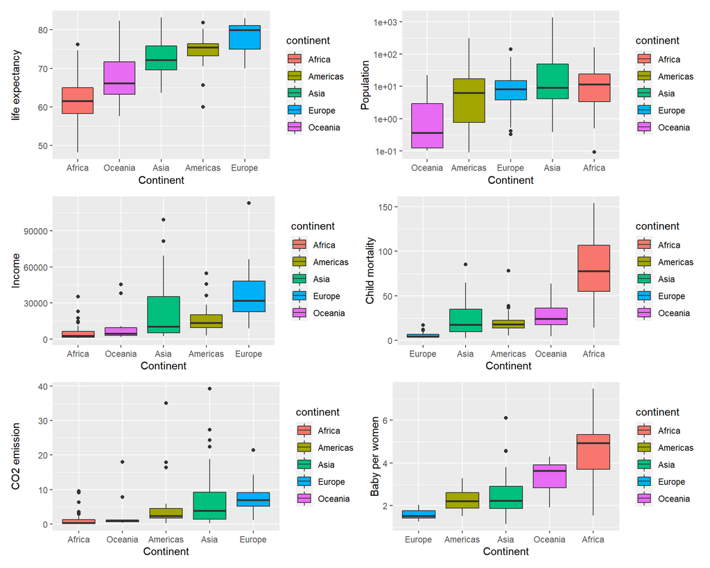

```r
p1 = Study1_data_2010 %>% ggplot(aes(x=reorder(continent, life_expectancy,
                            FUN = median, na.rm=T), y = life_expectancy, fill = continent)) +
  xlab("Continent") + ylab("life expectancy") +
  geom_boxplot()

p2 = Study1_data_2010 %>% ggplot(aes(x=reorder(continent, population,
                            FUN = median, na.rm=T), y = population, fill = continent)) +
  xlab("Continent") + ylab("Population") +
  geom_boxplot() +
  scale_y_continuous(trans="log10")

p3 = Study1_data_2010 %>% ggplot(aes(x=reorder(continent, income,
                            FUN = median, na.rm=T), y = income, fill = continent)) +
  xlab("Continent") + ylab("Income") +
  geom_boxplot()

p4 = Study1_data_2010 %>% ggplot(aes(x=reorder(continent, child_mortality,
                            FUN = median, na.rm=T), y = child_mortality, fill = continent)) +
  xlab("Continent") + ylab("Child mortality") +
  geom_boxplot()

p5 = Study1_data_2010 %>% ggplot(aes(x=reorder(continent, CO2,
                            FUN = median, na.rm=T), y = CO2, fill = continent)) +
  xlab("Continent") + ylab("CO2 emission") +
  geom_boxplot()

p6 = Study1_data_2010 %>% ggplot(aes(x=reorder(continent, baby,
                            FUN = median, na.rm=T), y = baby, fill = continent)) +
  xlab("Continent") + ylab("Baby per women") +
  geom_boxplot()



(p1 + p2)/(p3 + p4)/(p5 + p6)
```

Similar results, I got from the previous relationship between gapminder data and year. Europe maintains a very high the vast majority of level of gdpminder values.

## 5.2 Correctional coeffection between gdpminders values

According to 2010, this table presents the correlation coefficient between every two variables.

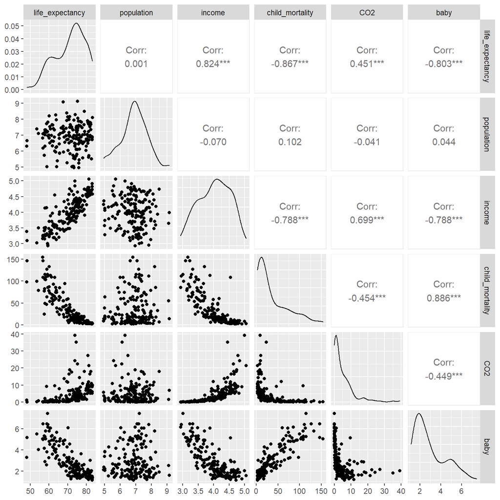

```r
ggpairs(Study1_data_2010%>%mutate(population=log10(population)+6,income=log10(income)), columns = c(3:8))
```

```r
#ggpairs(Study1_data_2010, columns = c(3:8), ggplot2::aes(colour = continent))
```

I create a table to show the positive correlation and negative correlation variables for each gdpminder value.

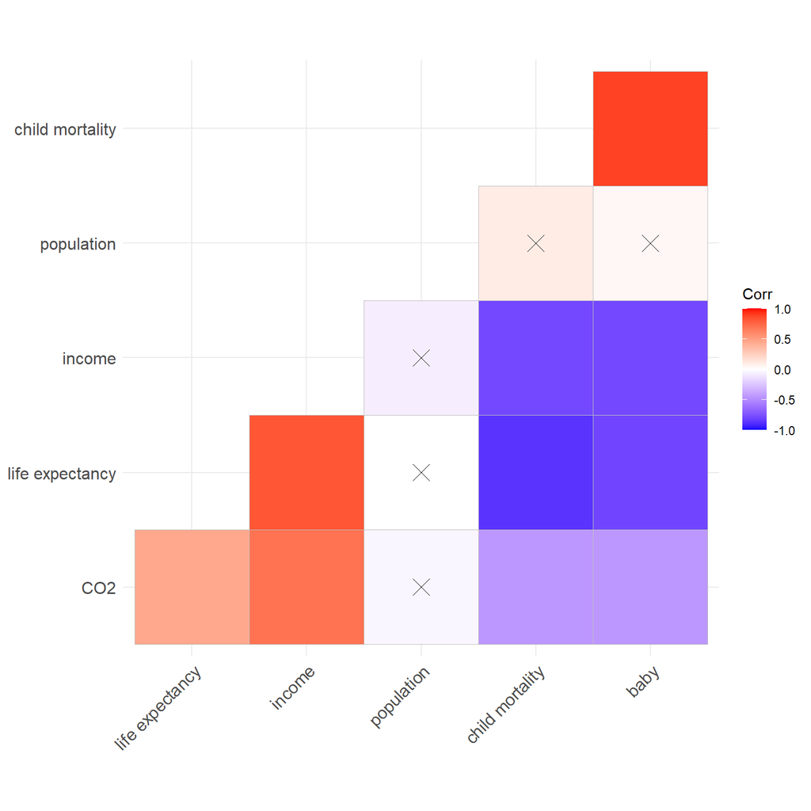

```r
Study1_data_2010Corr <- Study1_data_2010%>%mutate(population=log10(population)+6,income=log10(income))%>%select(life_expectancy:baby)

colnames(Study1_data_2010Corr) <- c('life expectancy','population','income','child mortality','CO2','baby')

corr <- cor(Study1_data_2010Corr, use="pairwise.complete.obs")
p.mat <- cor_pmat(Study1_data_2010Corr)

p7 = ggcorrplot(corr, hc.order = TRUE,
    type = "lower", p.mat = p.mat)
p7
```

## 5.3 Babies per woman vs variable(weight=population)

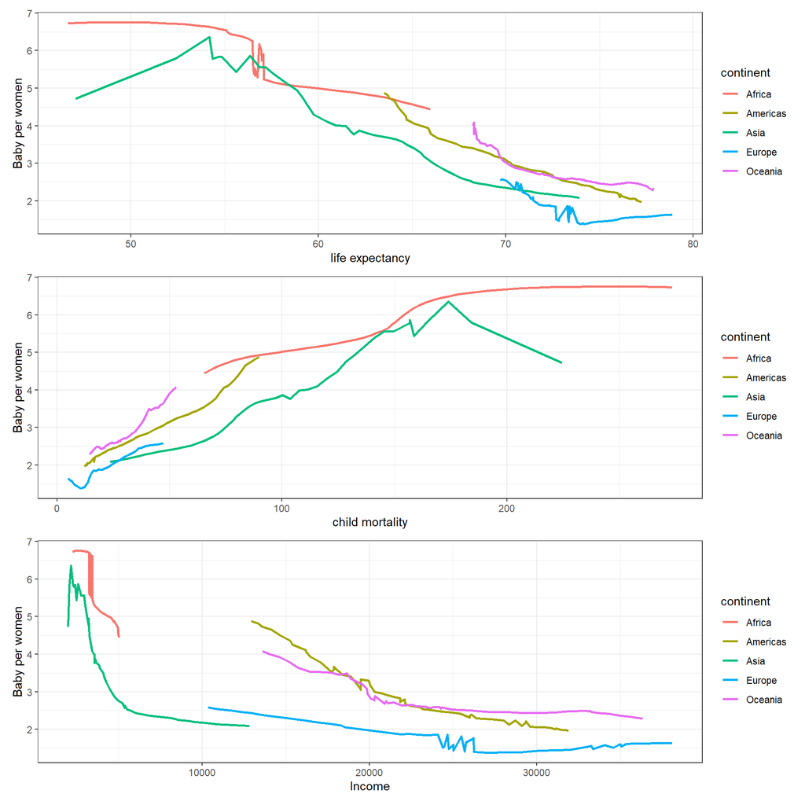

```r
p1 <- Study1_data %>%
    group_by(year, continent) %>%
    summarize(
      ave_life_expectancy = weighted.mean(life_expectancy, w = as.numeric(population), na.rm = TRUE),
      ave_baby = weighted.mean(baby, w = as.numeric(population), na.rm = TRUE)
    ) %>%
  ggplot(aes(x=ave_life_expectancy, y=ave_baby))+
      geom_line(aes(color=continent, group=continent), size=1) + xlab("life expectancy") + ylab("Baby per women") +
      theme_bw()


p2 <- Study1_data %>%
    group_by(year, continent) %>%
    summarize(
      ave_child_mortality = weighted.mean(child_mortality, w = as.numeric(population), na.rm = TRUE),
      ave_baby = weighted.mean(baby, w = as.numeric(population), na.rm = TRUE)
    ) %>%
  ggplot(aes(x=ave_child_mortality, y=ave_baby))+
      geom_line(aes(color=continent, group=continent), size=1) + xlab("child mortality") + ylab("Baby per women") +
      theme_bw()


p3 <- Study1_data %>%
    group_by(year, continent) %>%
    summarize(
      ave_income = weighted.mean(income, w = as.numeric(population), na.rm = TRUE),
      ave_baby = weighted.mean(baby, w = as.numeric(population), na.rm = TRUE)
    ) %>%
  ggplot(aes(x=ave_income, y=ave_baby))+
      geom_line(aes(color=continent, group=continent), size=1) + xlab("Income") + ylab("Baby per women") +
      theme_bw()

p1/p2/p3
```

From the plots, we can find that the relationship between life expectancy and Baby per woman is when life expectancy increases, then Baby per woman decreases over time. European countries maintain very outstanding results, having the highest life expectancy and the lowest fertility levels. However, there is an upward trend in fertility levels from almost median point in this line but it is still not very pronounced and it is necessary to combine other variables to better explain this phenomenon.

In the linear relationship between child mortality and fertility, in general as child mortality rises fertility rates also rise, to varying degrees on each continent. One possible explanation for the lack of fertility growth in Africa at around 200 child mortality is that at this time society is under load and at the limit of its capacity to bear more births at high child mortality.

In the linear relationship between income and fertility, in the long run, when economic growth is relatively stable and income expectations are relatively flat, approaching the premise that technology levels remain constant fertility is characterized by diminishing marginal utility the economy grows, income increases, and fertility declines.As long as the skill level remains stable, the marginal utility of fertility decreases for both high- and low-income households as the economy grows steadily.

# 6 Conclusion & Discussion

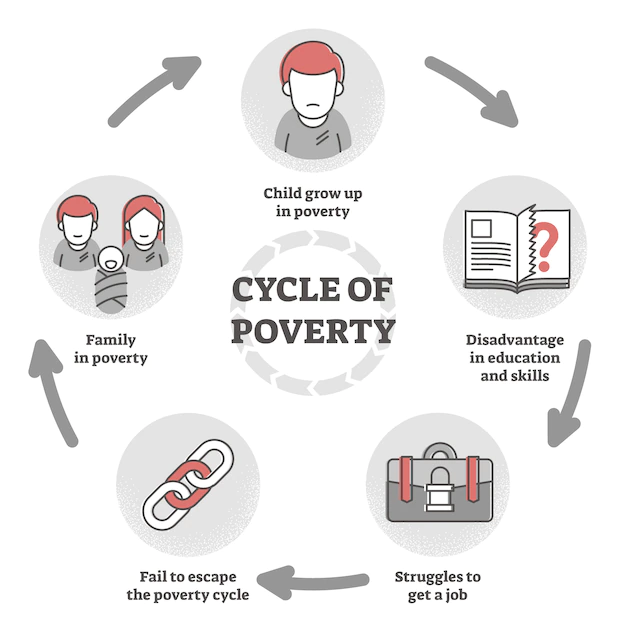

The ‘cycle of poverty’ is a model that represents a series of events that essentially holds a population in poverty. This research crudely illustrates the cycle of poverty where high fertility, low economic growth, poor health and other developmental issues are inter-related. Breaking out of the cycle is extremely difficult to do.